# Homework 1

Çağla Çetiner 19080388

**Question 1** With Markdown write a sentence that has one word in bold.

The oldest known pet **cat** existed 9500 years ago.

**Question 2** With Markdown write a sentence that has one word in italic.

Cats spend 70% of their lives *sleeping*.

**Question 3** With Markdown write a sentence that has one word in italic bold.

A cat was the Mayor of an *Alaskan* town for 20 years.

**Question 4** With Markdown write an unordered list with three items.

##### A few of your cat’s favorite things

* Cats love sleeping and napping.  
* Cats need to scratch.  
* Cats love high places for watching and hiding.

**Question 5** With Markdown write an ordered list with three items.

##### How Cats Choose Their Favorite Human

1.spend more time with them.  
2.match thie interests.  
3.talk to them.

**Question 6** With Markdown give a link to your favorite webpage.

If you are wondering more, you can check [this page.](https://www.purina.co.uk/articles/cats/behaviour/common-questions/fun-facts-about-cats)

**Question 7** With Markdown add a cat picture.

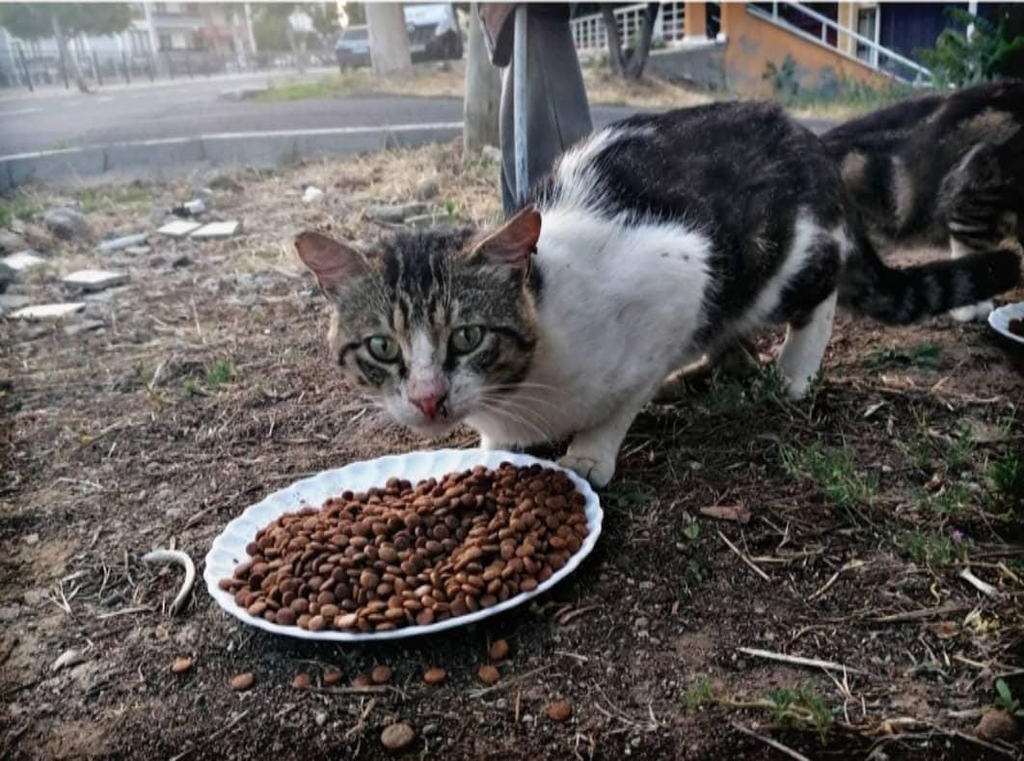

one of our street cats

**Question 8** With Rmarkdown insert a code chunk and give an example of a simple mathematical calculation in it.

```r
x <- 82
sqrt(9) + x/2 + 4^4
```

```
## [1] 300
```

**Question 9** With $LaTeX$ write your favorite equation in block form.
$$f(n) = n^6 + 2n^5 + 6 |_{n=5}$$

**Question 10** In a code chunk calculate 3 + 4.

```r
3+4
```

```
## [1] 7
```